# Chapter 4: Mixture Models

`r`r library(here) library(ggplot2) library(dplyr) library(mclust) library(mixtools) library(pscl) library(mosaics) library(HistData) library(bootstrap) library(vcd) library(ggbeeswarm) library(flexmix)

**Table of contents**

[1] Mixture Models  
[1.1] Summary  
[1.2] Finite Mixtures  
[1.3] Empirical distributions and the nonparametric bootstrap  
[1.4] Infinite Mixtures  
[1.5] Excercises  
[X] Misc.

**Mixture Models**<sup>Return</sup>

- Heterogeneity(diversity) is a problem w/ biological data analysis
  - Quantities in data do not show unimodal distribution
    - ex) CpG island/nonIsland in ch2 have 2 modes
      - Look at data as a simple mixture of few (X) components -> X in this case is 2 == **Finite mixture**
    - Other mixtures can a complex mixture of many (X) components -> X in this case can equal #Observations == **Infinite mixture**
- In ch1 used a simple generative model (Poisson distribution) to infer a detected epitope
  - In real life, a proper model fitting this data is not easily done
  - But simple models such as Poisson and Binomial distriburions can be used to build realistic models (Mixture Models)
- Mixtures are natural for flow cytometry data, biometric measurements, RNA-Seq, ChIP-Seq, microbiome analysis & more data types

**Summary**<sup>Return</sup>

- EM algorithm can be used to solve difficult optimization problem
  - iterations of pretending part1 of the solution is known - used to figure out part2 of the solution
  - Then alternate & pretend part2 of the solution is known - used to figure out part1 of the solution
  - Interation because this keeps occuring until solutions converge
- **Finite Mixture Models**
  - Model mixtures of >2 normal distributions w/ different variences & means
    - Decompose a sample from data by using mixture
      - Don’t need to know the latent/unknown variable –> This is because of EM algorithm
  - EM approach requirements
    - Know parametric form of distributions
    - Know number of components
    - CH5 - find groupings in data w/o relying on the requirements of the EM approach == Clustering
      - Strong relationship between clustering & mixture model statistics
- **Common Infinite Mixture Models**
  - Infinite mixture models used to contruct new distributions (ex) Gamma-Poisson or Laplace) from simple ones (Binomial, normal, Poisson)
    - examples
      - Mixtures of normals (Hierarchical model on means + Variences)
      - Beta-binomial mixtures (Probability p in binomial distriution is generated by beta(a,b) distribution)
      - Gamma-Poisson for read counts
      - Gamma-exponential for PCR
- **Uses of Mixture Models**
  - Dataset has layers of experimental variability (ex) technical replicates, technician, temporal, etc)
    - Lowest layer measurement of precision may be limited to physical detection limits (ex) baseline Absorbance)
      - May model w/ Poisson distribution if counting-based assay (discrete), or normal distribution if continous measurement
    - Top layer (may involve many layers) (ex) instrument-to-instrument variation, reagent kits, operator)
  - Mixture models show that there is diverse amount of variability(variences) in data
    - Shows that, need to propoerly transform data (ex) Varience stabilizing transformations) before further analysis
      - ex) RNA-seq sample in CH8 - normalize NGS reads in microbial ecology
  - Two-component model in multiple testing
    - CH6
- ECDF & Bootstrapping
  - Use observed sample for mixture -> generate many simulated samples = information about sampling distribution of estimate
    - Bootstrapping method
      - Method to evaluate estimates, including when no formulas are available (Non-parametric)

**Finite Mixtures**<sup>Return</sup>

### Simple examples & computer experiments

- ex) mixture model w/ 2 equal-sized components
  - Decompose generating process into steps
- Step 1
  - Flip a fair coin
  - Make a random normal distribution w/ mean=1, variance=0.25
  - Make a random normal distribution w/ mean =3, variance=0.25 (note mean is the parameter)
  - repeat these steps 10,000 times

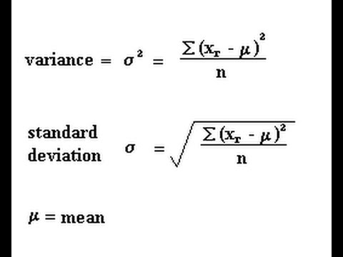

`r`r `r`r coinflips <- (runif(1e4) > 0.5) # generate 10,000 observations of uniform distribution (min=0, max=1) - since 0 to 1 values, anything more than half is TRUE(logical) -mixing fraction λ=0.5 table(coinflips)

```
coinflips
FALSE  TRUE
 4998  5002
```

`r`r `r`r # This function takes in #flips fl, if fl>=1 then simulate 1 observation using distribution1 parameters, if no flips specified # ex) oneFlip(0), then simulate 1 observation using distribution2 parameters # In R, TRUE=1 & FALSE=0 oneFlip <- function(fl, mean1=1, mean2=3, sd1=0.5, sd2=0.5){ #Sqrt var(0.25) = 0.5 sd if(fl){ rnorm(1, mean1, sd1) } else { rnorm(1, mean2, sd2) }}

`r`r `r`r #Generate mixture model from both normal distributions fairmix <- vapply(coinflips, oneFlip, numeric(1)) ggplot(tibble(value=fairmix), aes(x=value)) + geom_histogram(fill=, binwidth = 0.1)

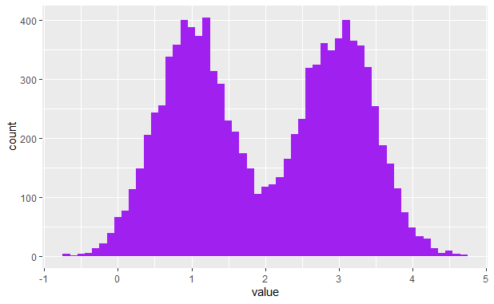

- 17. Use R-vector syntax instead of vapply loop & generate fairmix

`r`r `r`r # A) note looks different because variences used instead of standard dev means <- c(1,3) variences <- c(0.25, 0.25) values <- rnorm(length(coinflips), mean=ifelse(coinflips, means[1], means[2]), sd=ifelse(coinflips, variences[1], variences[2])) ggplot(tibble(value=values), aes(x=values)) + geom_histogram(fill=, binwidth = 0.1)

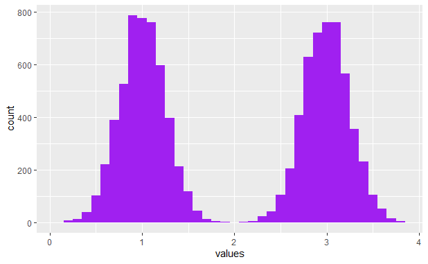

- 17. Use the vectorized code above, to simulate 1mil coin flips.
  - Make a histogram w/ 500 bins

`r`r `r`r # A) Use tibble dataframe to organize flips/simulated normal values fair <- tibble( cflips=(runif(1e6)>0.5), values1 =rnorm(length(cflips), mean=ifelse(cflips, means[1], means[2]), sd=ifelse(cflips, variences[1], variences[2]))) ggplot(fair, aes(x=values1)) + geom_histogram(fill=, bins=500)

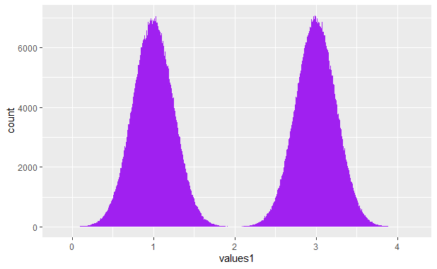

- Increase of #observations & bins means the histogram gets more smooth
  - **Smooth limiting histogram curve == Density function** of random variable (this case `fair$values`)
    - Density function for normal N(μ,σ) random variable can be written as ϕ(x)
      $$\begin{align}
      \phi(x)=\frac{1}{\sigma \sqrt{2\pi}}e^{-\frac{1}{2}(\frac{x-\mu}{\sigma})^2}
      \end{align}$$
- 17. Plot a histogram of TRUE values for coinflips, corresponding to simulated normal fair$values & add the line corresponding to ϕ(x)

`r`r `r`r # A) filter(dataframe, colname) only filters for TRUE in colname specified # aes(y=..density..) specifies vertical axis shows PROPORTION of counts # stat_function() superimposes a function on top of plot ggplot(dplyr::filter(fair, cflips), aes(x = values1)) + geom_histogram(aes(y = ..density..), fill = , binwidth = 0.01) + stat_function(fun = dnorm, args = list(mean = means[1], sd = variences[1]), color = )

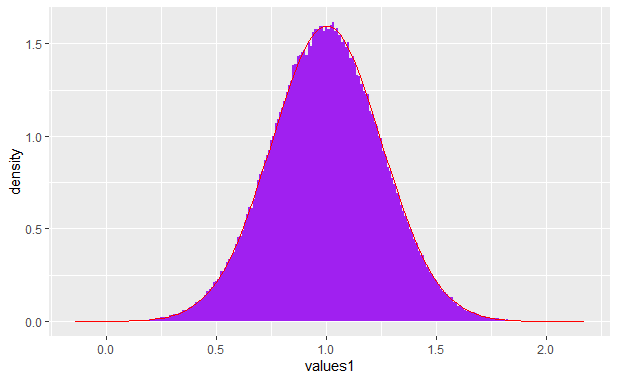

- Density formula for all simulated normal `fair$values` is a sum of both densities (2 normal distribs)

$$\begin{equation}
f(x)=\frac{1}{2}\phi_1(x)+\frac{1}{2}\phi_2(x)
\tag{4.1}
\end{equation}$$

- Where ϕ(x) is defined as the above formula
  - ϕ1 is the density of normal N(μ1=1,σ<sup>2</sup>=0.25)
  - ϕ2 is the density of normal N(μ1=3,σ<sup>2</sup>=0.25)

`r`r `r`r # Aside - 0.5*dnorm b/c 0.5 percent chance of Heads/Tails fairtheory <- tibble( x=seq(-1,5, length.out=1000), f=0.5*dnorm(x, mean=means[1], sd=variences[1])+ 0.5*dnorm(x, mean=means[2], sd=variences[2])) ggplot(fairtheory, aes(x=x, y=f)) + geom_line(color=, size=1.5) + ylab(density) + ggtitle(density of mixtue)

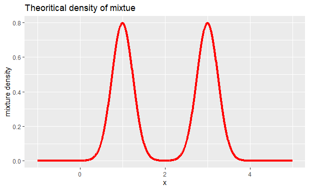

- In this case, the two component distribution (2 normals) have low overlap
  - Shows two peaks = bimodal distribution
  - Many mixture models don’t have a clear separation
- 17. Guess the mean parameter of two normal distributions which overlap and have the same variences
  - Use trial and error simulation of mixtures to see if the distributions overlap

`r`r `r`r # A) Red = points from heads flip, blue = points from tails flip - means(parameters) must be close for overlap means4.4 <- c(2.5,3) variences4.4 <- c(0.25,0.25) mystery <- tibble( coinflips4.4 = (rnorm(1000)>0.5), values4.4 =rnorm(length(coinflips4.4), mean=ifelse(coinflips4.4, means4.4[1], means4.4[2]), sd=ifelse(coinflips4.4, variences4.4[1], variences4.4[2]))) head(mystery,3) r br <- with(mystery, seq(min(values4.4), max(values4.4), length.out=30)) #using dataframe - min(colname) to max(colname) ggplot(mystery, aes(x = values4.4)) + geom_histogram(data = dplyr::filter(mystery, coinflips4.4), #filter all true fill = , alpha = 0.2, breaks = br) + geom_histogram(data = dplyr::filter(mystery, !coinflips4.4), #filter all false fill = , alpha = 0.2, breaks = br)

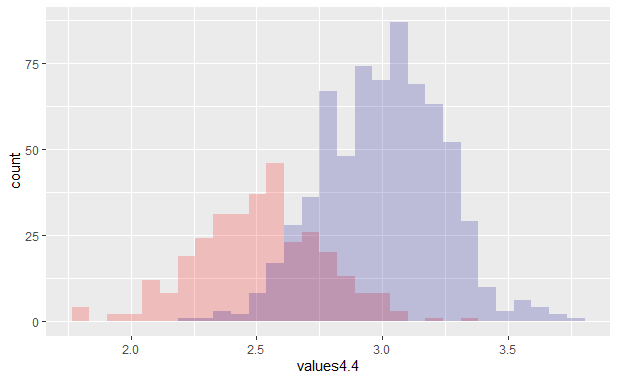

| coinflips4.4 | values4.4 |
| --- | --- |
| TRUE | 2.665162 |
| FALSE | 2.790415 |
| FALSE | 3.700348 |

`r`r `r`r # Another way of showing above figure ggplot(mystery, aes(x = values4.4, fill=coinflips4.4)) + geom_histogram(breaks=br, alpha=0.2) + scale_fill_manual(values=c(‘TRUE’=, ‘FALSE’=), guide=FALSE)

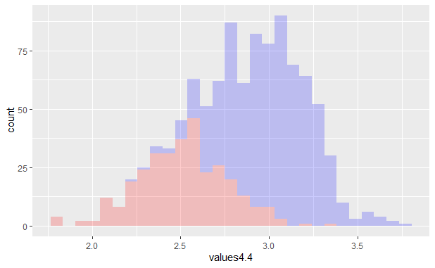

- Both methods of showing overlapping distributions utilize `confilips` column of TRUE/FALSE to separate components/groups by colour
  - In real data, this would be missing information

### Discover hidden groups labels (“black box”)

- Use **expectation-maximizatiom (EM) algorithm** - infers hidden groups (classes) mixed in dataset
  - EM algorithm is a iterative procedure between the following:
    1. Infers known probability for each observation in a group/component & estimates distribution parameters of groups/components (forward)
    2. Infers parameters of distribution & estimates probability for each observation in group/component (reverse)
- Ex) Measure variable Y on series of objects that may come from 2 groups
  - Group labels are unknown
    - Need to augement (via adding unmeasured variable = latent variable(U)) the dataset
    - Want to find values of latent variable(U) & unknown parameters of the mixture model densities
      - Use a maximum likelihood approach (from ch2) -> estimate parameters of fitting dataset Y
      - Use **bivariate distribution** -> distribution of couples (Y,U)
      - Probability density under a parametric model

$$\begin{equation}
f_\theta(y,u) = f_\theta(y\,|\,u) f_\theta(u)
\tag{4.2}
\end{equation}$$

- Where
  - theta = tuple of parameters for the model
    - ex) for a bivariate normal distribution, theta = the two means & 2 sd & **mixture fraction of mixture model** λ=0.5
    - θ=(μ1,μ2,σ1,σ2,λ)
- 17. Assume 2 unfair coins, probability of heads p1=0.125, p2=0.25
  - With probability PP -> pick coin1, 1-PP is probability of coin 2
  - Toss coin twice & record number of heads(K)
  - Simulate 100 instances of this w/ PP=1/8 - compute contingency of table (K)
    - Do the same when PP=1/4
    - If p1 & p2 & PP not given, can this be infered from the contingency table?

`r`r `r`r # A) Use for loop to test both PP probabilities probHead <- c(0.125, 0.25) for(PP in c(1/8, 1/4)){ whCoin = sample(x=2, size=100, replace=TRUE, prob=c(PP,1-PP)) #random sample of 100obs outputting 1 or 2 w/ input prob K = rbinom(length(whCoin), size=2, prob=probHead[whCoin]) #this simulates the contingency table for heads(K) using the probabilities used to calculate whCoin vector (ex) 1 = 1/8, 2= 1/8) print(table(K)) }

```
K
 0  1  2
51 43  6
K
 0  1  2
68 30  2
```

> Degrees of freedom of an estimate is the number of independent pieces of information that went into calculating the estimate. It’s not quite the same as the number of items in the sample. In order to get the df for the estimate, you have to subtract 1 from the number of items. Let’s say you were finding the mean weight loss for a low-carb diet. You could use 4 people, giving 3 degrees of freedom (4 – 1 = 3), or you could use one hundred people with df = 99.
- Mixture of normals -> ex) mixture of two normal distributions w/ unknown mean parameters, known sd of 1 for both distirbutions
  - (μ1=?,μ2=?,σ1=σ2=1)

`r`r `r`r # example of data generated using this model. Labels are (u) - similar to previous question where label was coinflips mus <- c(-0.5, 1.5) u <- sample(2, size=100, replace=TRUE) y <- rnorm(length(u), mean=mus[u]) duy <- tibble(u,y) head(duy)

| u | y |
| --- | --- |
| 2 | 1.3980630 |
| 2 | 0.6193850 |
| 1 | -0.9214307 |
| 2 | 0.5351434 |
| 1 | 0.9430178 |
| 2 | 2.1780752 |

- notice in the `coinflips` sample, the results were logical (TRUE/FALSE). Here, since the means are unknown - the values are 2 or 1
- If we know the labels (u), can estimate means using separate MLEs for each group
  - The overall MLE obtained by maximizing the following equation. Or by it’s log.
    - Maximization can be split into 2 independent pieces & solved (ex) 2 different MLE equations to solve)

$$\begin{equation}
f(y, u \,|\, \theta) =
\prod_{\{i:\,u_i=1\}} \phi_1(y_i)
\prod_{\{i:\,u_i=2\}} \phi_2(y_i),
\tag{4.3}
\end{equation}$$

`r`r `r`r group_by(duy, u) %>% summarise(mean(y)) #group the duy tibble at u column (group 1 or 2), then summarize the mean all y’s within group

| u | mean(y) |
| --- | --- |
| 1 | -0.4739179 |
| 2 | 1.8051589 |

- 17. Assume the mixing fraction is know as λ=0.5
  - 0.5Ф1 + 0.5Ф
  - Write out the log(likelihood)
    - what prevents solving for MLE here?
- 1. CH19 shows computation of likelihood of finite mixture models
  - To estimate a mixture model, we need weighted MLE - weights given by posterior label probabilities
  - repetition depends on parameters estimated
  - We wouldn’t know labels “u” or mixture proportion “λ” in real data
    - Need to have an inital guess for labels (u)
    - Need to estimate parameters
    - Need iterations through EM algorithm - this updates “best guess” for group labels & parameters
      - eventually, this effect plateaus into no improvement per cycling (Indicated by the marginal likelihood)
        - **Marginal likelihood** for observed y = sum overall possible values of (u) of the densities at (y,u)
- Can replace the “hard labels” for u observations (groups 1 & 2)
  - via group membership probabilities summing to 1
  - Probability p(u,x|θ) is the weight/participation of observed x in likelihood function
    - AKA soft averaging - make weighted averages where probabilities of each point is used as weight. Thus, we don’t have to decide if the point belongs to one group or another

  $$\begin{equation*}
  \text{marglike}(\theta;y)=f(y\,|\,\theta)=\sum_u f(y,u\,|\,\theta) \,\text{d}u.
  \end{equation*}$$
- Each iteration (present values marked *) includes the current best guess for unknown parameters (ex) μ1*, μ2*)
  - This is combined into θ* =(μ1*, μ2*, λ*)
    - Used to compute expection function E*(θ) (expectation = average/integrate over all possible values of u)

$$\begin{equation*}
E^*(\theta)=E_{\theta^*,Y}[\log p(u,y\,|\,\theta^*)]=\sum_u p(u\,|\,y ,\theta^*)
\log p(u,y\,|\,\theta^*),
\end{equation*}$$

- Value of θ maximizing E* found in *maximization step*
  - Iterations through E & M repeated until E* increases are small -> indicates plateauing likelihood = reaching local max
    - Iteration path *depends on starting point* but always end up at the same end point (assuming 1 end point)
    - Good practice to repeat procedure several times from different start points to see if same answer received
- 17. Multiple packages for EM algoritm (mclust, EMcluster, EMMIXskew)
  - Pick one and test EM function w/ different starting values
  - Use function `normalmixEM` from `mixtools` package for output comparison

`r`r `r`r #install.packages() #install.packages() # A) y <- c(rnorm(100, mean=-0.2, sd=0.5), rnorm(50, mean=0.5, sd=1))

`r`r `r`r mixtools <- normalmixEM(y, k=2, lambda=c(0.5,0.5), mu=c(-0.01,0.01), sigma=c(1,1))

```
number of iterations= 774
```

`r`r `r`r paste(mixtools$lambda, lambda)

```
[1] \0.774506160782519 when lambda\ \0.225493839217481 when lambda\
```

`r`r `r`r paste(mixtools$mu, mean)

```
[1] \-0.216348235569516 when mean\ \0.932897192957862 when mean\
```

`r`r `r`r paste(mixtools$sigma, sd)

```
[1] \0.543003401379571 when sd\ \0.710642524374504 when sd\
```

`r`r `r`r paste(mixtools$loglik, loglikelihood)

```
[1] \-165.256664574208 when loglikelihood\
```

`r`r `r`r mclust <- Mclust(data=y)

```
fitting ...
```

`r`r `r`r mclust$parameters

```
$pro
[1] 0.8602688 0.1397312

$mean
         1          2
-0.1573281  1.2749194

$variance
$variance$modelName
[1] \E\

$variance$d
[1] 1

$variance$G
[1] 2

$variance$sigmasq
[1] 0.3263279
```

`r`r `r`r paste(mclust$loglik, loglikelihood)

```
[1] \-165.325209137362 when loglikelihood\
```

### Models for zero-inflated data

- Ecological & molecular data often in counts
  - Sometimes, contains counts of 0
  - Mixture models of data with zeros

$$\begin{equation*}
f_{\text{zi}}(y) = \lambda \, \delta(y) + (1-\lambda) \, f_{\text{count}}(y),
\end{equation*}$$

- Where Delta = Dirac delta function -> represents probability distribution w/ mass at 0
  - 0’s in first mixture component (delta) = “structural” for this example
    - This is due to certain species not living in certain habitats (this example)
  - 0’s in the second component (fcount)
    - This is due to not finding certain members of a species in some locations (this example)
- The `pscl & zicounts` package has datasets & functions for working w/ zero-inflated counts

### Ex) ChIP-Seq data

- Sequences of DNA from chromatin immunoprecipitation -> map location along genomic DNA
  - example dataset from `mosaics` package= data measured on chromosome22 via ChIP-seq of antibodies for STAT1 protein & H3K4me3 histone modification to some cell line
    - `binTFBS` dataset = binding sites for one chromosome22

`r`r `r`r # install.packages() ; BiocManager::install(c(, )) datafiles = (here(, , c(12878Stat1StdAlnRep1_chr22_sorted.bam_fragL200_bin200.txt, 12878InputStdAlnRep1_chr22_sorted.bam_fragL200_bin200.txt))) binTFBS <- readBins(type = c(,\input), fileName = datafiles)

```
Info: reading and preprocessing bin-level data...
Info: data contains only one chromosome.
Info: done!
```

`r`r `r`r binTFBS

```
Summary: bin-level data (class: BinData)
----------------------------------------
- # of chromosomes in the data: 1
- total effective tag counts: 462479
  (sum of ChIP tag counts of all bins)
- control sample is incorporated
- mappability score is NOT incorporated
- GC content score is NOT incorporated
- uni-reads are assumed
----------------------------------------
```

`r`r `r`r # Create histogram of per-bin counts bincts <- print(binTFBS) ggplot(bincts, aes(x=tagCount)) + geom_histogram(binwidth=1, fill=) + ggtitle(#binding sites found in 200nt window along chrom22 ChIP-seq)

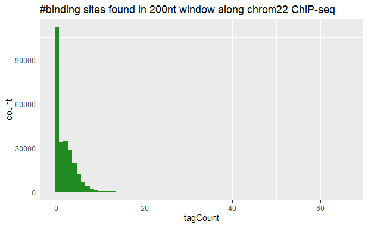

- Note at tagCount0 there is a high y-axis count of 0
  - However, not sure if the # of 0’s is really high b/c of frequencies of other small #’s (1, 2, …)
- 17. Redo histogram counts using log base10 scale on y-axis
  - Estimate π0 (PP0) proportion of bins w/ 0 counts

`r`r `r`r # A) ggplot(bincts, aes(x=tagCount)) + scale_y_log10() + geom_histogram(binwidth=1, fill=)

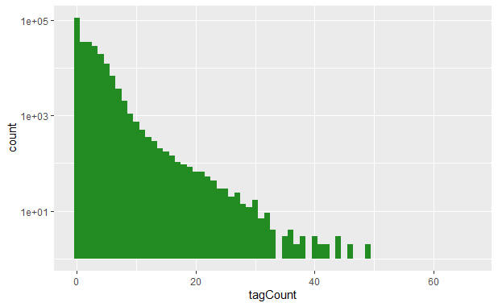

### More than 2 components

- So far, mixtures w/ 2 components but what if more?
  - ex) Weighing N=7000 nucleotides from mixtures of dNMPs (each type has different weight, all measured w/ same sd=3)

`r`r `r`r masses <- c(A=331, C=307, G=347, T=322) probs <- c(A=0.12, C=0.38, G=0.36, T=0.14) N <- 7000 sd <- 3 nuclt <- sample(x=length(probs), size=N, replace=TRUE, prob=probs) quadwts <- rnorm(length(nuclt), mean=masses[nuclt], sd=sd) ggplot(tibble(quadwts=quadwts), aes(x=quadwts)) + geom_histogram(bins=100, fill=)

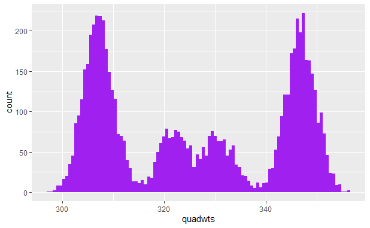

- 17. Repeat the above with N=1000 nucleotide measurements - what is the difference in outcome?

[figure not shown]

- 17. Repeat the above when N=7000 with sd=10 - what is the difference?

`r`r `r`r # A) More overlap between distributions N <- 7000 sd <- 10 nuclt7k10 <- sample(x=length(probs), size=N, replace=TRUE, prob=probs) quadwts7k10 <- rnorm(length(nuclt7k10), mean=masses[nuclt7k10], sd=sd) ggplot(tibble(quadwts7k10=quadwts7k10), aes(x=quadwts7k10)) + geom_histogram(bins=100, fill=)

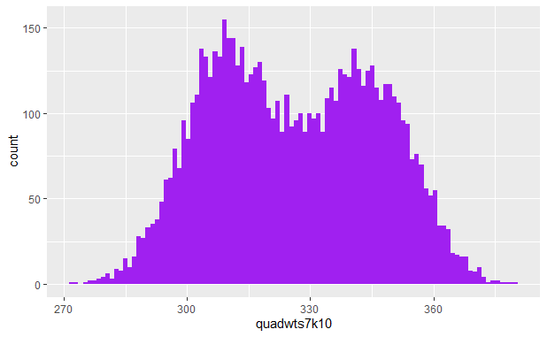

- 17. Plot the theoretical density curve of N=7000, sd=3

`r`r `r`r means <- c(331,307,347,322) sd <- c(3, 3, 3, 3) Q4.11<- tibble( x=seq(min(quadwts),max(quadwts), length.out=1000), f=0.12*dnorm(x, mean=means[1], sd=sd[1])+ 0.38*dnorm(x, mean=means[2], sd=sd[2]) + 0.36*dnorm(x, mean=means[3], sd=sd[3]) + 0.14*dnorm(x, mean=means[4], sd=sd[4])) ggplot(Q4.11, aes(x=x, y=f)) + geom_line(color=, size=1.5) + ylab(density) + ggtitle(density of mixtue)

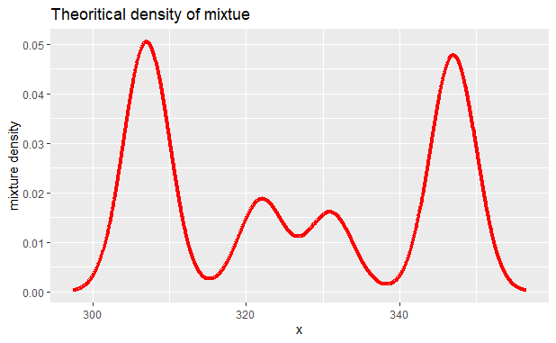

- In this case, enough measurements w/ good precision to dsitinguish the 4 nts modes using the theoretical density of mixture
  - Decomposed into 4 distributions
  - This is less clear when less datapoints in data/more noisy data

**Empirical distributions and the nonparametric bootstrap**<sup>Return</sup>

- Consider extreme case of mixture model
  - Model sample of n data points as mixture of n point masses
    - Can use amost any set of data -> ex) Darwin’s Zea mays data (`HistData` package)
      - Compared heights of 15 pairs of Zea mays plants (15 self-hybridized vs 15 crossed)

`r`r `r`r # install.packages() # Plot distribution of 15 differences in height ZeaMays$diff

```
 [1]  6.125 -8.375  1.000  2.000  0.750  2.875  3.500  5.125  1.750  3.625
[11]  7.000  3.000  9.375  7.500 -6.000
```

`r`r `r`r ggplot(ZeaMays, aes(x=diff, ymax=1/15, ymin=0)) + geom_linerange(size=1, col=) + ylim(0,0.1)

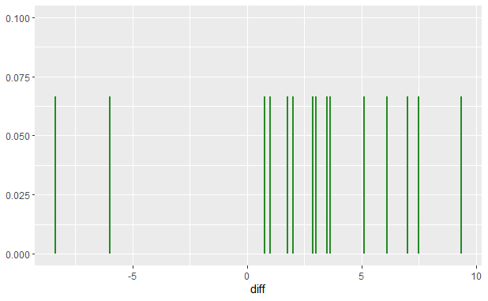

- The **emperical cumulative distribution function (ECDF)** for sample of size n

$$\begin{equation}
\hat{F}_n(x)= \frac{1}{n}\sum_{i=1}^n {\mathbb 1}_{x \leq x_i},
\tag{4.4}
\end{equation}$$

- ECDF plots -> write density of sample as

$$\begin{equation}
\hat{f}_n(x) =\frac{1}{n}\sum_{i=1}^n \delta_{x_i}(x)
\tag{4.5}
\end{equation}$$

- Density of probability distribution is the derivative (if exists) of distribution function
  - Consider delta(a) as derivative of step function 1(x <= a) in (4.4)
    - It’s completely flat almost everywhere, except at point a where the step occurs (value is infinite)
  - Eqn (4.5) shows that dataset can be considered as mixture of *n point masses*
    - one point at each observed value x1, x2,…,xn (shown by the plot above)
- Statistics of the sample (mean, min, median) can be written as function of ECDF
  - ex)
    $$\begin{equation}\bar{x} = \int \delta_{x_i}(x)\,\text{d}x\end{equation}$$
  - ex) if n is odd#, median value is
    $$\begin{equation}x_{(\frac{n+1}{2})}\end{equation}$$
- The **true sampling distribution** of statistic T(hat) is hard to find
  - Needs many different data samples to compute this statistic (sampling variability)
- **Bootstrap** principle approximates true sampling distribution of T(hat)
  - creates new samples drawn from original dataset
    - reuse data (considered a mixture distribution of delta’s) to make “new datasets”
    - Take samples from original data to look for sampling distriubtion of statistic T(hat) computed on the dataset
  - This is known as **nonparametric bootstrap resampling approach**
- Basically - T(hat) the statistic of the distribution is calculated/estimated from various sets of data within their own matracies(F) - each is a distribution
  - Different samples from F are from different data -> leads to different estimates of T(hat) == sampling variabiilty
  - The distributions of all T(hat)’s from all data is called the sampling distribution
- So to counteract this sampling variability of creating multiple T(hat) from different datasets
  - nonparametric bootstraping simulates the sampling variability -> pick samples not from true distribution F but from emperical distribution F(hat)<sub>n</sub>
- ex) estimate sampling distribution of median of Zea mays differences
  - Use simulation
    - Draw B=1000 samples of size 15 from 15 values(0:15) (each is component - 15 component mixture)
    - Find median of each of these 1000 samples w/ 15 values each
    - Look for bootstrap distribtuion of the 1000 medians

`r`r `r`r B <- 1000 meds <- replicate(B, { i = sample(15, size=15, replace=TRUE) median(ZeaMays$diff[i]) }) ggplot(tibble(medians=meds), aes(x=medians)) + geom_histogram(bins=30, fill=)

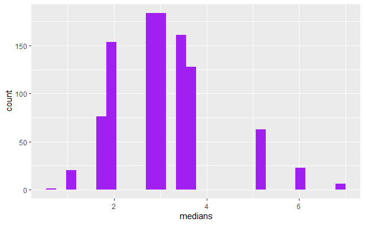

- 17. Estimate a 99% confidence interval for the median based on the simulations
  - What can be concluded by looking at overlap between this interval & 0?

`r`r `r`r # ???? - Bootstrap percentile/quantile method # 99% CI means 100%-99% = trim 1% off ends of the distribution (0.5% each upper/lower = 0.005) # In quantiles this equates to 0.005 quantile & 1-0.005 = 0.995 # The conclusion = IDK quantile(meds,c(0.005,0.995))

```
 0.5% 99.5%
    1     7
```

- Use `bootstrap` package to redo analysis using the function `bootstrap()` for both median & mean
  - What are differences between sampling distributions of mean & median?

`r`r `r`r #install.packages() a <- bootstrap(ZeaMays$diff, nboot=B, theta=mean) ggplot(tibble(mean=a$thetastar), aes(x=mean)) + geom_histogram(bins=30, fill=)

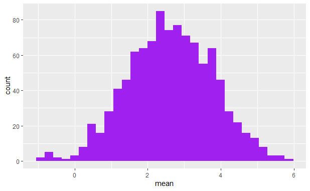

`r`r `r`r b <- bootstrap(ZeaMays$diff, nboot=B, theta=median) ggplot(tibble(mean=b$thetastar), aes(x=mean)) + geom_histogram(bins=30, fill=)

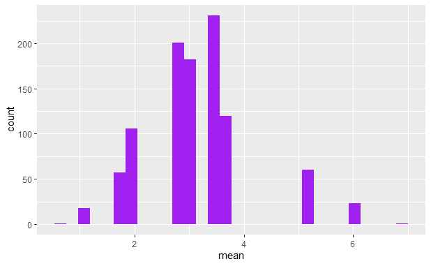

- Why nonparametric?
  - Theoretical statistics -> nonparametric methods = methods allowing for infinitely many degrees of freedom/numbers of unknown parameters
  - When #parameters become large or larger than amount of data -> nonparametric
  - Bootstrap uses mixture w/ n components so w/ sample size (n) -> nonparametric method
  - Nonparametric methods do use parameters (all statistical methods estimate unknown quantities)
  - When using non-parametric methods - often replace calculations via simulations (ex) bootstrap)
    - This is instead of generating all possible samples from emperical distribution
      - Possible in Theory - finite number of samples
    - Use Monte Carlo simulation to make bootstrap resamples of data
- 17. If sample has n=3 different values, how many different bootstrap resamples are possible?
  - Repeat this solution using n=15
- 1. Set of all bootstrap resamples = set of all vectors of n integers (sum is n)
  - Denoted by k=(k1, k2,…,kn) is the #of times the observations (x1, x2,…,xn) occur in a bootstrap sample
    - each k is a box (similar to multinomial distribtuion)
      - n boxes to drop n balls
  - Can count #configurations via counting #of ways separating n balls into boxes
    - ex) write down n times (a ball) & n-1 times (a separator (|)) between them
      - So 2n-1 posiions to fill
        - Must choose either ball or separator
    - If n=3
      - Possible placement would be ball/ball/|/|/ball (5 positions filled by ball/separator)-> k=(2,0,1)
        - n=ball, n-1=separator so 3 balls & 2 separators -> vector of n=3, 2 balls in 1st pos, 1 ball in last
  - In general this number is

$$\begin{equation}
{2n-1} \choose {n-1}
\end{equation}$$

`r`r `r`r # A) n=3 & n=15 -> nCr # 2n-1 when n=3 -> 5 == n total number of positions to be filled # k = n = 3 number of samples taken in one iteration c(N3=choose(n=5,k=3), N15=choose(29,15))

```
      N3      N15
      10 77558760
```

[figure not shown]

- permutations = ordering of objects -> n!
  - nPr -> out of n objects, how many ways to pick r of n objects **Order is important**
  - nCr -> same as nPr but **Order is not important**
- 17. What are two types of errors that can occur when using the bootstrap method in the `bootstrap` package?
  - What parameter can you change to improve one of the errors?
- 1. Errors
  - Error1: Monte Carlo simulations of subsets of data via random resampling used to approximate exhaustive bootstrap
    - By increasing the size of `nboot` argument of `boostrap()` -> this reduces Monte Carlo error
      - **Keep in mind, exhaustive boostrap is still no exact** b/c using approximate distribution function of data instead of true distribution
  - Error2: If sample size is small or original sample is biased - approximation will be poor
    - Doesn’t matter how large `nboot` is - this can’t resolve the problem
  - `nboot in bootstrap()` is the number of iterations/sampling desired

**Infinite mixtures**<sup>Return</sup>

- Mixture models can be useful even if the goal is not to assign a label to each observation
  - “Allowing as many labels as observations”
  - **If #mixture components ≥ #observations = Infinite mixture** ### Infinite mixture of normals
  - ex) Create a sample (w) from an exponential distribution

`r`r `r`r #note rexp() evaluates mean as 1/lambda where lambda=rate w <- rexp(10000, rate=1)

- Now (w) will serve as variences of normal variables w/ mean(μ) - simulated via rnorm

`r`r `r`r mu <- 0.3 lps <- rnorm(length(w), mean=mu, sd=sqrt(w)) ggplot(data.frame(lps), aes(x=lps)) + geom_histogram(fill=, binwidth=0.1)

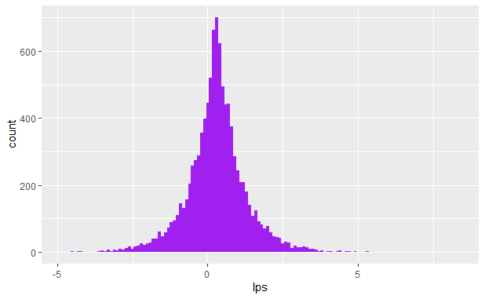

- This is a useful distribution w/ well-understood properties
  - Discovered by Laplace - person who proved that **median is a good estimator of the location parameter theta**
    - **also proved median absolute deviation can be used to estimate the scale parameter (Ф) of mixture models (MLE?)**

$$\begin{equation}
f_Y(y)=\frac{1}{2\phi}\exp\left(-\frac{|y-\theta|}{\phi}\right),\qquad\phi>0
\end{equation}$$

- Lapace density
  - Knew the above equation (probability density) has median as a location parameter (theta) & median absolute deviation is the scale parameter (Ф)
  - From this formula
    - L1 (absolute value of difference) Distance has similar position in Laplace density as
    - L2 (square of difference) in the normal density
- Note, in Bayesian regression using Laplace distribution as a prior on the coefficients
  - Causes an L1 penalty -> lasso
  - If Normal distribution as a prior, it will cause a L2 penalty -> ridge regression
- 17. Write random variable w/ distribution as symmetric Laplace density
  - Write as function of normal & exponential random variables
- 1. Write hierarchical model w/ variences generated as exponential variables (W),
     $$\begin{equation}
     Y = \sqrt{W} \cdot Z, \qquad W \sim Exp(1), \qquad Z \sim N(0,1).
     \tag{4.6}
     \end{equation}$$

### Asymmetric Laplace

- Laplace distribution - variences of normal components depend on (W) -> means are unaffected
  - where (W) is generated from an exponential distribution
  - **Add the parameter (theta), which controls location/centers of the components**
  - ex) Make `alps` dataset - use hierarchical model w/ (W) as exponential variable -> varience of normal
    - generate (w) from exponential distribution of mean 1 rexp(rate=1)
    - N(θ+wμ,σw)

`r`r `r`r mu = 0.3; sigma=0.4; theta=-1 w <- rexp(1e4, rate=1) alps <- rnorm(length(w), mean=(theta+mu*w), sd=(sigma*sqrt(w))) ggplot(tibble(alps), aes(x=alps)) + geom_histogram(fill=, binwidth=0.1)

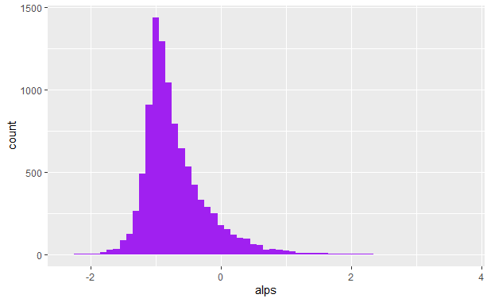

- This is a scale mixture of many normal w/ means & variences dependent (X~AL(theta, mu, sigma))
- In hierarchical mixture distributions where data has it’s own mean + vatience -> useful in biological settings

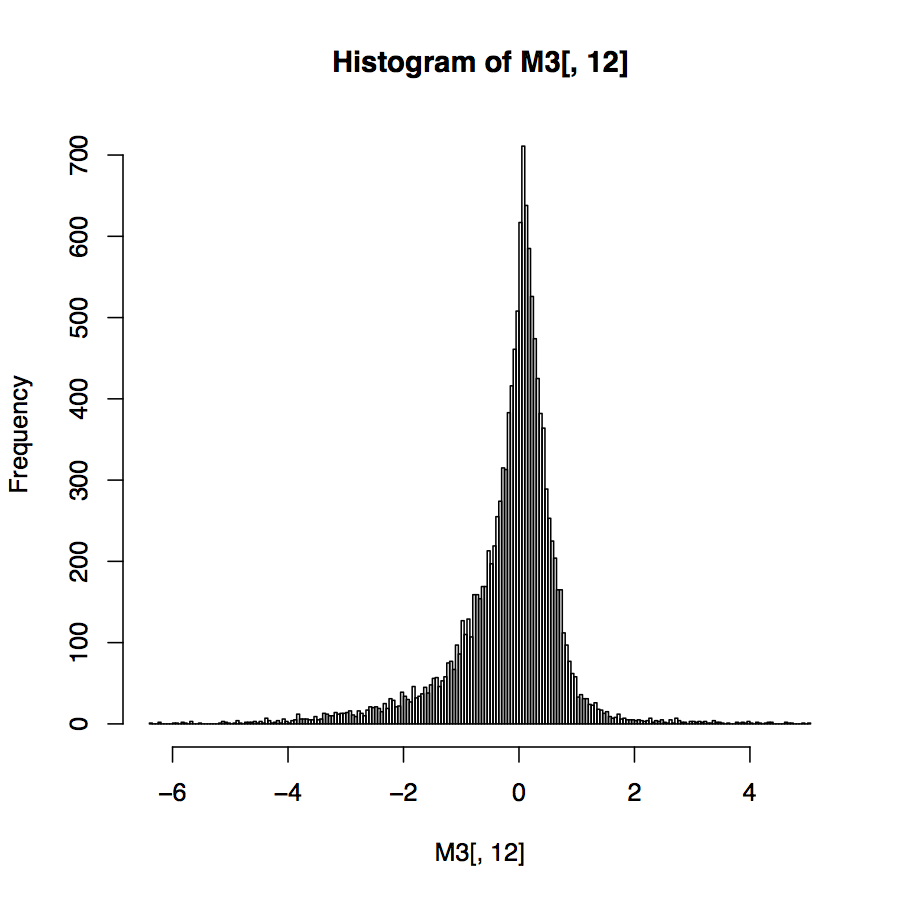

log-ratios Microarray

- 17. Look at log-ratio of gene expression values from microarray w/ distribution as above image
  - Explain the histogram in this form
- A) Sharper curve seems to indicate that scale parameter is <0, other than that IDK
- Laplace distribution shows that considering generative process can show how varience & mean are linked
  - expectation & varience of asymmetic Laplace distribution AL(theta, mu, sigma) ->

    $$\begin{equation}
    E(Y ) = \theta + \mu \quad\quad\text{and}\quad\quad\text{var}(Y)=\sigma^2+\mu^2.
    \tag{4.7}
    \end{equation}$$
- **Varience depends on the mean(mu), unless mu=0 (symmetric Laplace distribution)**
  - Mean-varience dependence is common in physical measurements (ex) microarray, fluorescence intensity, HTS read counts, etc)

### Infinite Mixtures of Poisson Variables

- Similar 2-level hieratchical model needed to model real-world count data
  - Lower level -> simple Poisson & Binomial distributions can be used a building blocks
    - Problem = parameters may depdent on latent process
    - ex) Ecology: Want to study variations in fish species of each lake via estimate true abundances
      - Can model w/ true abundances using Poisson, but true abundances vary from lake-to-lake
      - Want to see if climate change/altitude will affect variations -> requires to see if effects of variations lake-to-lake
      - Different Poisson rate parameters(lambda) - can be modelled as coming from a distribution of rates
        - This hierarchical model allows addition of supplementary steps of hierarchy
          - ex) Want to know different types of fish or model effects of altitude/env factors separately
  - Poisson mixtures also good in modelling
    - HTS data (ex) RNA seq)

### Gamma distribution: two parameters (shape & scale)

- Extension of one-parameter exponential distribution
  - This distribution has 2 oparameters -> more flexible
    - Useful bulding block for upper level hierarchical model
    - +ve value & continous
  - Density of exponential distribution has max at 0 & then decreases to 0 as value increase to infinity
    - Gamma distribution has max at some finite value
- Simulate using examples

`r`r ggplot(tibble(x=rgamma(n=1e4, shape=2, rate=1/3)), aes(x=x)) + geom_histogram(bins=100, fill=)

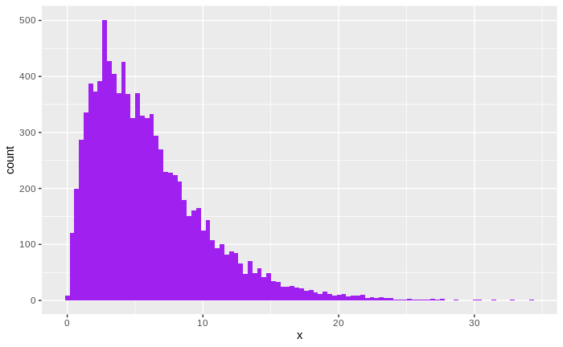

`r`r

ggplot(tibble(x=rgamma(n=1e4, shape = 10, rate = 3/2)), aes(x=x)) + geom_histogram(bins=100, fill=)

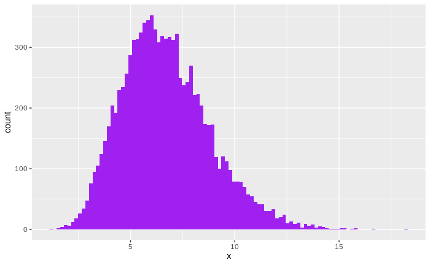

- Gamma-Poisson mixture: Hierarchical model
  - 2 level scheme
    - Generate set of parameters (lambda1, 2,…) from gamma distribution
    - Use parameters to generate set of Poisson(lambda) random variables (one per lambda)

`r`r `r`r lambda <- rgamma(1e4, shape=10, rate=3/2) gp <- rpois(length(lambda), lambda = lambda) ggplot(tibble(x=gp), aes(x=x)) + geom_histogram(bins=100, fill=)

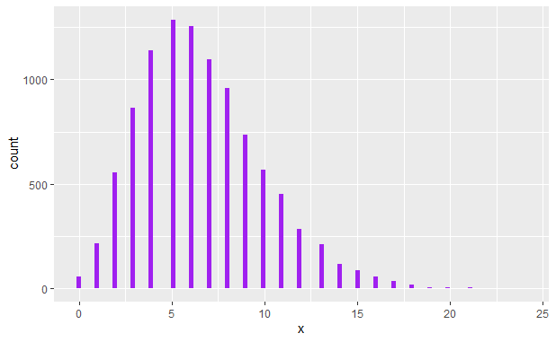

- 17. Are values generated from gamma-Poisson mixture continous or discrete? (gamma=continous, Poisson=discrete)
  - What is another name for this distribution? (test using `goodfit()` from vcd package)

`r`r `r`r # A) Another name for gamma-poisson is  
ofit <- goodfit(gp, ) ofit$par

```
$size
[1] 10.32106

$prob
[1] 0.6092442
```

`r`r `r`r plot(ofit, xlab=\, main=of fit plot /w rootogram) #shows theoretical probabilities of gp distribution as red dots. Square roots of observed frequences = height of rectangle bars. Bars closely align w/ horizontal axis = good fit

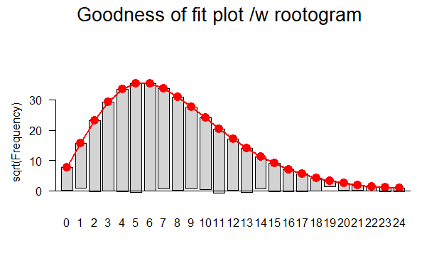

- Gamma-poisson distribution is also known as the “negative binomial distribution/Negative binomial”
  - Formula for equation is similar to binomial distribution
  - Gamma-Poisson is more defining of the underlying principles
  - This is a discrete distribution
    - Only takes values on natural numbers (but gamma distribution by itself works on all positives)
  - Probability distribution formula
    $$\begin{equation}
    \text{P}(K=k)=\left(\begin{array}{c}k+a-1\\k\end{array}\right) \, p^a \, (1-p)^k,
    \tag{4.8}
    \end{equation}$$
- Formula depends on 2 parameters (a elements of the real+ve) & (p elements of [0,1])
  - The two parameters can be expressed by mean(mu) = pa/(1-p) & parameter called dispersion (a=1/a)
    - Varience of distribution depends on these parameters (varience = mu+(a*mu<sup>2</sup>))

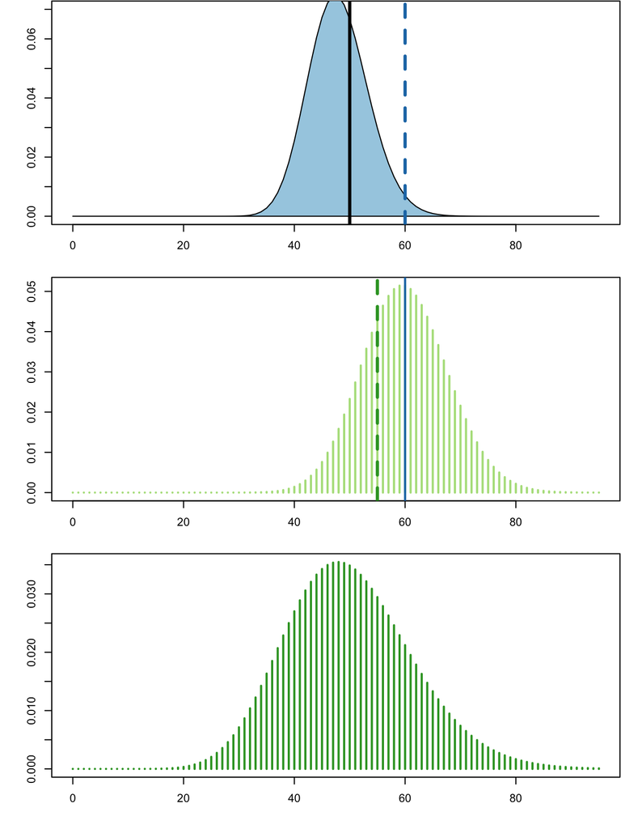

- Gamma-poisson distribution hierarchical model visualization
  - Top = density of gamma distribution w/ mean=50(black line) & var=30
    - In one experimental replicate, a value of 60 is obtained (dashed blue line) -> latent variable
  - Observed outcome distributed by Poisson distribution w/ rate parameter=60 (shown in middle graph)
    - In one experiment, the outcome may have a value of 55 (green dashed line)
  - If repeat these 2 random processes subsequently & many times -> outcomes distributed as bottom graph = gamma-Poisson distriubtion
- 17. Analytical derivations
- A) Skipped

### Varience-stabilizing tranformations

- Key issue to control when analyzing experimental data -> variability between replicates which should have the same underlying true value
  - ex) See if there is any true differences between replicates/differing conditions
- Data from hierarchical models in this chapter have very heterogenous variences -> problematic
  - **Varience-stabilizing transformations** can help

`r`r `r`r #ex) Series of Poisson variables w/ rates lambdas lambdas <- seq(100,900,by=100) simdat = lapply(lambdas, function(l) tibble(y = rpois(n = 40, lambda=l), lambda = l)) %>% bind_rows #output of lapply loop is a tibbles, one for each lambdas - the pipe operator uses the function bind_rows -> results in dataframe of all list elements stacked ggplot(simdat, aes(x=lambda, y=y)) + geom_beeswarm(alpha=0.6, color=)

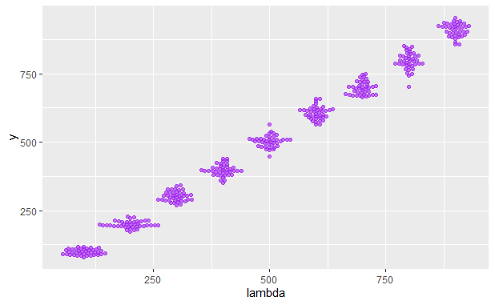

`r`r `r`r ggplot(simdat, aes(x=lambda, y=sqrt(y))) + geom_beeswarm(alpha=0.6, color=)

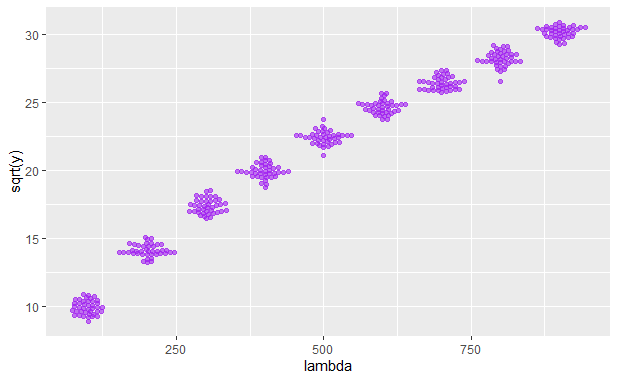

- The y-scaled graph shows **heteroscedasity = standard deviations(or varience) of dataset are different for different regions of data space** - note the shapes vary unless using the sqrt(y) scale
  - Increase along x-axis w/ the mean(lambda)
    - For Poisson distribution - know that the sd is the sqrt(mean) (different dependencies depending on data)
  - Different variences is problematic if we want to apply later analysis techniques which assume variences are the same (ex) regression/stat test)
  - In the above figures, the number of replicates in each beeswarm(40) is large
    - but if we used fewer replicates, the heteroscedasity will be harder to see
  - Once we do a sqrt(y) transformation in the above graph, this amkes the transformed variables have approximately the same varience

`r`r `r`r # Use tranformation y->2srt(y) which gives varience = ~1 summarise(group_by(simdat, lambda), sd(y), sd(2*sqrt(y)))

| lambda | sd(y) | sd(2 * sqrt(y)) |
| --- | --- | --- |
| 100 | 10.21936 | 1.0283167 |
| 200 | 12.56876 | 0.8889845 |
| 300 | 18.34483 | 1.0513302 |
| 400 | 20.38097 | 1.0228347 |
| 500 | 21.25854 | 0.9476257 |
| 600 | 23.48245 | 0.9518685 |
| 700 | 23.72112 | 0.8945710 |
| 800 | 30.91841 | 1.1017881 |
| 900 | 23.67705 | 0.7874445 |

[figure not shown]

- 17. Repeat code above for `simdat` w/ replicates >40
  - Can use gamma-Poisson distribution to generate gamma-Poisson variables(u) & plot 95% CI around mean
    - This catches greater range of values for mean value(mu) w/o creating dense sequence (use geometric series mu+1=2mu)

`r`r `r`r # A) muvalues <- 2^seq(0, 10, by=1) simgp <- lapply(muvalues, function(mu){ u = rnbinom(n=1e4, mu=mu, size=4) tibble(mean=mean(u), sd=sd(u), lower = quantile(u, 0.025), upper = quantile(u, 0.975), mu=mu) }) %>% bind_rows head(as.data.frame(simgp), 2) r ggplot(simgp, aes(x=mu, y=mean, ymin=lower, ymax=upper)) + geom_point() + geom_errorbar()

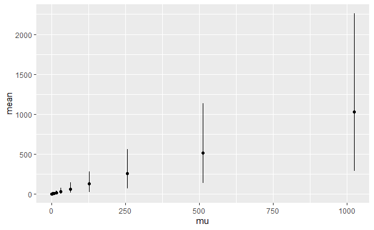

|  | mean | sd | lower | upper | mu |
| --- | --- | --- | --- | --- | --- |
| 1 | 0.9973 | 1.116520 | 0 | 4 | 1 |
| 2 | 2.0390 | 1.772398 | 0 | 6 | 2 |

- 17. How to find transformation for data that stabilizes varience, similar to sqrt() for Poisson distributed data?
  - 1. Divide values corresponding to `mu[1]` (centered around `simgp$mean[1]`) by sd `simgp$sd[1]`
    - & Values corresponding to `mu[2]` (centered around `simgp$mean[2]`) by sd `simgp$sd[2]`, etc..
    - Resulting values have a sd(AKA varience) of 1
      - Prevents defining 11 separate transformations -> can use single piecewise-lienar + continous function

`r`r `r`r simgp <- mutate(simgp, slopes=1/sd, transf = cumsum(slopes*mean)) ggplot(simgp, aes(x=mean, y=transf)) + geom_point() + geom_line() + xlab(\) + ggtitle(-lienar function used to stabilize data varience)

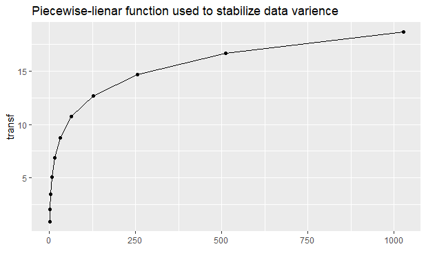

- This function resembles sqrt(), in particular the lower end
  - At the upper end, it looks more like a log
- Mathematical method of this is done through calculus -> **delta method**
  - Skipped

**Exercises**<sup>Return</sup>